```python
import itertools
import numpy as np
import matplotlib.pyplot as plt
from matplotlib.ticker import NullFormatter
import pandas as pd
import numpy as np
import matplotlib.ticker as ticker
from sklearn import preprocessing
%matplotlib inline
```

```python
import pandas as pd
df = pd.read_csv('C:\\Users\\tanma\\Desktop\\ALL\\2nd same isi\\Machine learning assigment\\loan_train (1).csv')
df.head()
```

|  | Unnamed: 0.1 | Unnamed: 0 | loan_status | Principal | terms | effective_date | due_date | age | education | Gender |
| --- | --- | --- | --- | --- | --- | --- | --- | --- | --- | --- |
| 0 | 0 | 0 | PAIDOFF | 1000 | 30 | 9/8/2016 | 10/7/2016 | 45 | High School or Below | male |
| 1 | 2 | 2 | PAIDOFF | 1000 | 30 | 9/8/2016 | 10/7/2016 | 33 | Bechalor | female |
| 2 | 3 | 3 | PAIDOFF | 1000 | 15 | 9/8/2016 | 9/22/2016 | 27 | college | male |
| 3 | 4 | 4 | PAIDOFF | 1000 | 30 | 9/9/2016 | 10/8/2016 | 28 | college | female |
| 4 | 6 | 6 | PAIDOFF | 1000 | 30 | 9/9/2016 | 10/8/2016 | 29 | college | male |

# Dataset

This dataset contains historical loan data for 346 customers, capturing whether their loans were successfully paid off or ended up in default (collection). The dataset includes the following key features:

Loan_status: Indicates the loan outcome—Paid Off (repaid successfully) or Collection (defaulted).

Principal: The original loan amount borrowed by the customer.

Terms: The repayment schedule, which can be weekly (7 days), biweekly, or monthly.

Effective_date: The date when the loan was approved and became active.

Due_date: The final repayment due date (since this is a one-time payoff loan structure).

Age: The age of the applicant at the time of borrowing.

Education: The education level of the borrower.

Gender: The gender of the applicant (likely categories: Male, Female, or Other).

```python
df['due_date'] = pd.to_datetime(df['due_date'])
df['effective_date'] = pd.to_datetime(df['effective_date'])
df.head()
```

|  | Unnamed: 0.1 | Unnamed: 0 | loan_status | Principal | terms | effective_date | due_date | age | education | Gender |
| --- | --- | --- | --- | --- | --- | --- | --- | --- | --- | --- |
| 0 | 0 | 0 | PAIDOFF | 1000 | 30 | 2016-09-08 | 2016-10-07 | 45 | High School or Below | male |
| 1 | 2 | 2 | PAIDOFF | 1000 | 30 | 2016-09-08 | 2016-10-07 | 33 | Bechalor | female |
| 2 | 3 | 3 | PAIDOFF | 1000 | 15 | 2016-09-08 | 2016-09-22 | 27 | college | male |
| 3 | 4 | 4 | PAIDOFF | 1000 | 30 | 2016-09-09 | 2016-10-08 | 28 | college | female |
| 4 | 6 | 6 | PAIDOFF | 1000 | 30 | 2016-09-09 | 2016-10-08 | 29 | college | male |

```python
df['loan_status'].value_counts()
```

```
loan_status
PAIDOFF       260
COLLECTION     86
Name: count, dtype: int64
```

```python
# notice: installing seaborn might takes a few minutes
!conda install -c anaconda seaborn -y
```

```
Solving environment: ...working... done

# All requested packages already installed.
```

[output not shown]

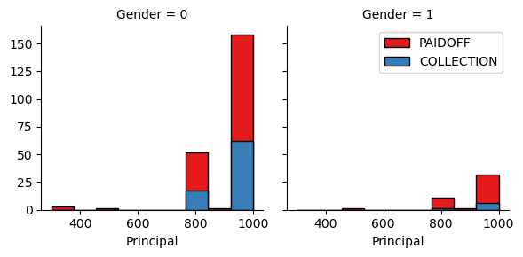

```python
import seaborn as sns

bins = np.linspace(df.Principal.min(), df.Principal.max(), 10)
g = sns.FacetGrid(df, col="Gender", hue="loan_status", palette="Set1", col_wrap=2)
g.map(plt.hist, 'Principal', bins=bins, ec="k")

g.axes[-1].legend()
plt.show()
```

## Conclusion

For both genders:Loans with lower principal amounts are more frequently paid off.As principal amount increases, the proportion of loans going into collection tends to increase.For Males:A broader spread of loan amounts is observed.More unpaid loans (collection status) appear in the higher principal ranges.For Females:Loan amounts might be slightly lower on average.Fewer instances of loans in collection, suggesting better repayment behavior in this sample.Loan repayment seems negatively associated with higher principal amounts.Gender differences in loan behavior may exist but should be confirmed with statistical testing.

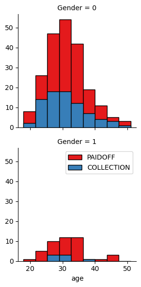

```python
bins = np.linspace(df.age.min(), df.age.max(), 10)
g = sns.FacetGrid(df, col="Gender", hue="loan_status", palette="Set1", col_wrap=1)
g.map(plt.hist, 'age', bins=bins, ec="k")

g.axes[-1].legend()
plt.show()
```

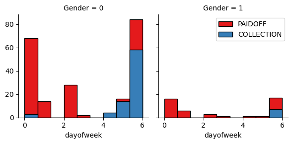

```python
df['dayofweek'] = df['effective_date'].dt.dayofweek
bins = np.linspace(df.dayofweek.min(), df.dayofweek.max(), 10)
g = sns.FacetGrid(df, col="Gender", hue="loan_status", palette="Set1", col_wrap=2)
g.map(plt.hist, 'dayofweek', bins=bins, ec="k")
g.axes[-1].legend()
plt.show()
```

```python
df['weekend'] = df['dayofweek'].apply(lambda x: 1 if (x>3)  else 0)
df.head()
```

|  | Unnamed: 0.1 | Unnamed: 0 | loan_status | Principal | terms | effective_date | due_date | age | education | Gender | dayofweek | weekend |
| --- | --- | --- | --- | --- | --- | --- | --- | --- | --- | --- | --- | --- |
| 0 | 0 | 0 | PAIDOFF | 1000 | 30 | 2016-09-08 | 2016-10-07 | 45 | High School or Below | 0 | 3 | 0 |
| 1 | 2 | 2 | PAIDOFF | 1000 | 30 | 2016-09-08 | 2016-10-07 | 33 | Bechalor | 1 | 3 | 0 |
| 2 | 3 | 3 | PAIDOFF | 1000 | 15 | 2016-09-08 | 2016-09-22 | 27 | college | 0 | 3 | 0 |
| 3 | 4 | 4 | PAIDOFF | 1000 | 30 | 2016-09-09 | 2016-10-08 | 28 | college | 1 | 4 | 1 |
| 4 | 6 | 6 | PAIDOFF | 1000 | 30 | 2016-09-09 | 2016-10-08 | 29 | college | 0 | 4 | 1 |

```python
df.groupby(['Gender'])['loan_status'].value_counts(normalize=True)
```

```
Gender  loan_status
0       PAIDOFF        0.731293
        COLLECTION     0.268707
1       PAIDOFF        0.865385
        COLLECTION     0.134615
Name: proportion, dtype: float64
```

```python
df['Gender'].replace(to_replace=['male','female'], value=[0,1],inplace=True)
df.head()
```

|  | Unnamed: 0.1 | Unnamed: 0 | loan_status | Principal | terms | effective_date | due_date | age | education | Gender | dayofweek | weekend |
| --- | --- | --- | --- | --- | --- | --- | --- | --- | --- | --- | --- | --- |
| 0 | 0 | 0 | PAIDOFF | 1000 | 30 | 2016-09-08 | 2016-10-07 | 45 | High School or Below | 0 | 3 | 0 |
| 1 | 2 | 2 | PAIDOFF | 1000 | 30 | 2016-09-08 | 2016-10-07 | 33 | Bechalor | 1 | 3 | 0 |
| 2 | 3 | 3 | PAIDOFF | 1000 | 15 | 2016-09-08 | 2016-09-22 | 27 | college | 0 | 3 | 0 |
| 3 | 4 | 4 | PAIDOFF | 1000 | 30 | 2016-09-09 | 2016-10-08 | 28 | college | 1 | 4 | 1 |
| 4 | 6 | 6 | PAIDOFF | 1000 | 30 | 2016-09-09 | 2016-10-08 | 29 | college | 0 | 4 | 1 |

```python
df.groupby(['education'])['loan_status'].value_counts(normalize=True)
```

```
education             loan_status
Bechalor              PAIDOFF        0.750000
                      COLLECTION     0.250000
High School or Below  PAIDOFF        0.741722
                      COLLECTION     0.258278
Master or Above       COLLECTION     0.500000
                      PAIDOFF        0.500000
college               PAIDOFF        0.765101
                      COLLECTION     0.234899
Name: proportion, dtype: float64
```

```python
df[['Principal','terms','age','Gender','education']].head()
```

|  | Principal | terms | age | Gender | education |
| --- | --- | --- | --- | --- | --- |
| 0 | 1000 | 30 | 45 | 0 | High School or Below |
| 1 | 1000 | 30 | 33 | 1 | Bechalor |
| 2 | 1000 | 15 | 27 | 0 | college |
| 3 | 1000 | 30 | 28 | 1 | college |
| 4 | 1000 | 30 | 29 | 0 | college |

```python
Feature = df[['Principal','terms','age','Gender','weekend']]
Feature = pd.concat([Feature,pd.get_dummies(df['education'])], axis=1)
Feature.drop(['Master or Above'], axis = 1,inplace=True)
Feature.head()
```

|  | Principal | terms | age | Gender | weekend | Bechalor | High School or Below | college |
| --- | --- | --- | --- | --- | --- | --- | --- | --- |
| 0 | 1000 | 30 | 45 | 0 | 0 | False | True | False |
| 1 | 1000 | 30 | 33 | 1 | 0 | True | False | False |
| 2 | 1000 | 15 | 27 | 0 | 0 | False | False | True |
| 3 | 1000 | 30 | 28 | 1 | 1 | False | False | True |
| 4 | 1000 | 30 | 29 | 0 | 1 | False | False | True |

```python
X = Feature
X[0:5]
```

|  | Principal | terms | age | Gender | weekend | Bechalor | High School or Below | college |
| --- | --- | --- | --- | --- | --- | --- | --- | --- |
| 0 | 1000 | 30 | 45 | 0 | 0 | False | True | False |
| 1 | 1000 | 30 | 33 | 1 | 0 | True | False | False |
| 2 | 1000 | 15 | 27 | 0 | 0 | False | False | True |
| 3 | 1000 | 30 | 28 | 1 | 1 | False | False | True |
| 4 | 1000 | 30 | 29 | 0 | 1 | False | False | True |

```python
y = df['loan_status'].values
y[0:5]
```

```
array(['PAIDOFF', 'PAIDOFF', 'PAIDOFF', 'PAIDOFF', 'PAIDOFF'],
      dtype=object)
```

```python
X= preprocessing.StandardScaler().fit(X).transform(X)
X[0:5]
print(X.shape)
```

```
(346, 8)
```

```python
from sklearn.model_selection import train_test_split
from sklearn.neighbors import KNeighborsClassifier
import matplotlib.pyplot as plt
from sklearn import metrics
```

```python
train_X , test_X , train_y , test_y = train_test_split(X,y,test_size=0.2, random_state = 1)
```

```
Training acc: 0.815
Testing acc: 0.757
```

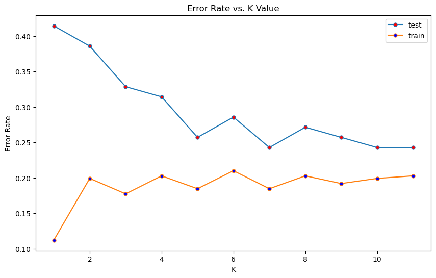

```python
error_rate_test = []
KK = 12

for i in range(1,KK):

    knn = KNeighborsClassifier(n_neighbors=i)
    knn.fit(train_X, train_y)
    pred_i = knn.predict(test_X)
    error_rate_test.append(np.mean(pred_i != test_y))



error_rate_train = []
for y in range(1,KK):

    knn = KNeighborsClassifier(n_neighbors=y)
    knn.fit(train_X, train_y)
    pred_i = knn.predict(train_X)
    #print(pred_i != train_y)
    error_rate_train.append(np.mean(pred_i != train_y))
    plt.figure(figsize=(10,6))
plt.plot(range(1,KK),error_rate_test, linestyle='-', marker='o',label="test",
         markerfacecolor='red', markersize=5)
plt.plot(range(1,KK),error_rate_train, linestyle='-', marker='o',label="train",
         markerfacecolor='blue', markersize=5)
plt.title('Error Rate vs. K Value')
plt.xlabel('K')
plt.ylabel('Error Rate')
plt.legend()

#model select k=7
KNN_model = KNeighborsClassifier(n_neighbors = 7)
KNN_model.fit(train_X, train_y)

#performance

accuracy1 = metrics.accuracy_score(train_y, KNN_model.predict(train_X))
print('Training acc: %.3f' % accuracy1)

accuracy2 = metrics.accuracy_score(test_y, KNN_model.predict(test_X))
print('Testing acc: %.3f' % accuracy2)
```

## Decision Tree

```python
from sklearn.tree import DecisionTreeClassifier
```

```python
DTC = DecisionTreeClassifier()
DTC_model = DTC.fit(train_X, train_y)
```

```python
#performance

accuracy1 = metrics.accuracy_score(train_y, DTC_model.predict(train_X))
print('Training acc: %.2f' % accuracy1)

accuracy2 = metrics.accuracy_score(test_y, DTC_model.predict(test_X))
print('Testing acc: %.2f' % accuracy2)
```

```
Training acc: 0.91
Testing acc: 0.69
```

## Support Vector Machine

```python
import sklearn.svm as svm
```

```python
SVM_model = svm.SVC()
SVM_model.fit(train_X, train_y)
```

```
SVC()
```

```python
#performance

accuracy1 = metrics.accuracy_score(train_y, SVM_model.predict(train_X))
print('Training acc: %.2f' % accuracy1)

accuracy2 = metrics.accuracy_score(test_y, SVM_model.predict(test_X))
print('Testing acc: %.2f' % accuracy2)
```

```
Training acc: 0.76
Testing acc: 0.74
```

## Logistic Regression

```python
from sklearn.linear_model import LogisticRegression
```

```python
logreg_model = LogisticRegression()
logreg_model.fit(train_X, train_y)
```

```
LogisticRegression()
```

```python
yhat = logreg_model.predict(test_X)
yhat
```

```
array(['PAIDOFF', 'PAIDOFF', 'PAIDOFF', 'PAIDOFF', 'COLLECTION',
       'PAIDOFF', 'PAIDOFF', 'PAIDOFF', 'PAIDOFF', 'PAIDOFF', 'PAIDOFF',
       'PAIDOFF', 'COLLECTION', 'PAIDOFF', 'PAIDOFF', 'PAIDOFF',
       'PAIDOFF', 'PAIDOFF', 'PAIDOFF', 'PAIDOFF', 'PAIDOFF', 'PAIDOFF',
       'PAIDOFF', 'PAIDOFF', 'PAIDOFF', 'PAIDOFF', 'PAIDOFF', 'PAIDOFF',
       'PAIDOFF', 'PAIDOFF', 'PAIDOFF', 'PAIDOFF', 'PAIDOFF', 'PAIDOFF',
       'PAIDOFF', 'PAIDOFF', 'PAIDOFF', 'PAIDOFF', 'PAIDOFF', 'PAIDOFF',
       'PAIDOFF', 'PAIDOFF', 'PAIDOFF', 'PAIDOFF', 'PAIDOFF', 'PAIDOFF',
       'PAIDOFF', 'PAIDOFF', 'PAIDOFF', 'PAIDOFF', 'PAIDOFF', 'PAIDOFF',
       'PAIDOFF', 'PAIDOFF', 'PAIDOFF', 'PAIDOFF', 'PAIDOFF', 'PAIDOFF',
       'PAIDOFF', 'PAIDOFF', 'PAIDOFF', 'PAIDOFF', 'PAIDOFF', 'PAIDOFF',
       'PAIDOFF', 'PAIDOFF', 'PAIDOFF', 'PAIDOFF', 'PAIDOFF', 'PAIDOFF'],
      dtype=object)
```

```python
#performance

accuracy1 = metrics.accuracy_score(train_y, logreg_model.predict(train_X))
print('Training acc: %.2f' % accuracy1)

accuracy2 = metrics.accuracy_score(test_y, logreg_model.predict(test_X))
print('Testing acc: %.2f' % accuracy2)
```

```
Training acc: 0.73
Testing acc: 0.77
```

```python
from sklearn.metrics import jaccard_score
from sklearn.metrics import f1_score
from sklearn.metrics import log_loss
```

```python
test_df = pd.read_csv('C:\\Users\\tanma\\Desktop\\ALL\\2nd same isi\\Machine learning assigment\\loan_train (1).csv')
test_df.head()
```

|  | Unnamed: 0.1 | Unnamed: 0 | loan_status | Principal | terms | effective_date | due_date | age | education | Gender |
| --- | --- | --- | --- | --- | --- | --- | --- | --- | --- | --- |
| 0 | 0 | 0 | PAIDOFF | 1000 | 30 | 9/8/2016 | 10/7/2016 | 45 | High School or Below | male |
| 1 | 2 | 2 | PAIDOFF | 1000 | 30 | 9/8/2016 | 10/7/2016 | 33 | Bechalor | female |
| 2 | 3 | 3 | PAIDOFF | 1000 | 15 | 9/8/2016 | 9/22/2016 | 27 | college | male |
| 3 | 4 | 4 | PAIDOFF | 1000 | 30 | 9/9/2016 | 10/8/2016 | 28 | college | female |
| 4 | 6 | 6 | PAIDOFF | 1000 | 30 | 9/9/2016 | 10/8/2016 | 29 | college | male |

```python
test_df['effective_date'] = pd.to_datetime(test_df['effective_date'])
test_df['Gender'].replace(to_replace=['male','female'], value=[0,1],inplace=True)
test_df['dayofweek'] = test_df['effective_date'].dt.dayofweek
test_df['weekend'] = test_df['dayofweek'].apply(lambda x: 1 if (x>3)  else 0)
te_Feature = test_df[['Principal','terms','age','Gender','weekend']]
te_Feature = pd.concat([te_Feature,pd.get_dummies(test_df['education'])], axis=1)
te_Feature.drop(['Master or Above'], axis = 1,inplace=True)
te_Feature = preprocessing.StandardScaler().fit(te_Feature).transform(te_Feature)
```

```python
#KNN
KNN_acc = np.mean(KNN_model.predict(te_Feature) == test_df['loan_status'])
print('KNN acc: %.2f' %KNN_acc)
#DT
DT_acc = np.mean(DTC_model.predict(te_Feature) == test_df['loan_status'])
print('DT acc: %.2f' %DT_acc)
#SVM
SVM_acc = np.mean(SVM_model.predict(te_Feature) == test_df['loan_status'])
print('SVM acc: %.2f' %SVM_acc)
#Logreg
logreg_acc = np.mean(logreg_model.predict(te_Feature) == test_df['loan_status'])
print('logreg acc: %.2f' %DT_acc)
```

[output not shown]

```python
#########################KNN
f1_KNN = f1_score(np.array(test_df['loan_status']), np.array(KNN_model.predict(te_Feature)), pos_label = 'PAIDOFF')
jaccard_KNN = jaccard_score(np.array(test_df['loan_status']), np.array(KNN_model.predict(te_Feature)), pos_label = 'PAIDOFF')

#########################Decision Tree
f1_DT = f1_score(np.array(test_df['loan_status']), np.array(DTC_model.predict(te_Feature)), pos_label = 'PAIDOFF')
jaccard_DT = jaccard_score(np.array(test_df['loan_status']), np.array(DTC_model.predict(te_Feature)), pos_label = 'PAIDOFF')

#################################################SVM
f1_SVM = f1_score(np.array(test_df['loan_status']), np.array(SVM_model.predict(te_Feature)), pos_label = 'PAIDOFF')
jaccard_SVM = jaccard_score(np.array(test_df['loan_status']), np.array(SVM_model.predict(te_Feature)), pos_label = 'PAIDOFF')

###########################################3Logreg
f1_logreg = f1_score(np.array(test_df['loan_status']), np.array(logreg_model.predict(te_Feature)), pos_label = 'PAIDOFF')
jaccard_logreg = jaccard_score(np.array(test_df['loan_status']), np.array(logreg_model.predict(te_Feature)), pos_label = 'PAIDOFF')


print(f'f1_KNN: {round(f1_KNN,3)}, jaccard_KNN: {round(jaccard_KNN,3)}')
print(f'f1_DT: {round(f1_DT,3)}, jaccard_DT: {round(jaccard_DT,3)}')
print(f'f1_SVM: {round(f1_SVM,3)}, jaccard_SVM: {round(jaccard_SVM,3)}')
print(f'f1_Logreg: {round(f1_logreg,3)}, jaccard_Logreg: {round(jaccard_logreg,3)}')
```

```
f1_KNN: 0.875, jaccard_KNN: 0.779
f1_DT: 0.906, jaccard_DT: 0.829
f1_SVM: 0.862, jaccard_SVM: 0.758
f1_Logreg: 0.849, jaccard_Logreg: 0.738
```

```python
###########################################LogLoss for logistic regression

logloss_logreg = log_loss(test_df['loan_status'],  logreg_model.predict_proba(te_Feature))


print(f'log loss: {round(logloss_logreg,3)}')
```

```
log loss: 0.435
```

```python
data = {
    'Algorithm': ['KNN', 'Decision Tree', 'SVM', 'LogisticRegression'],
    'Jaccard': [0.779,0.829,0.758,0.738],
    'F1-score': [0.875,0.906,0.862,0.849],
    'LogLoss': ['NA', 'NA', 'NA', 0.435]
}

report_df = pd.DataFrame(data)
print(report_df)
```

```
            Algorithm  Jaccard  F1-score LogLoss
0                 KNN    0.779     0.875      NA
1       Decision Tree    0.829     0.906      NA
2                 SVM    0.758     0.862      NA
3  LogisticRegression    0.738     0.849   0.435
```